# REACH and RStudio: PS and Survival Analysis

Basics of OHDSI Study Design & Statistical Analysis

Erik Westlund

2026-10-07

# Welcome

## Course Materials

The slides and the code behind every example are available on GitHub at github.com/erikwestlund/2026-bids-bootcamp.

## Today’s Plan

1. Study design and causal inference
2. Common types of research outcomes in OHDSI
3. Confounding and approaches to addressing it
4. A preview of propensity scores and CohortMethod

On Monday we described cohorts with tables and figures. Today and Friday we move from description to estimation: measuring the effect of a treatment on an outcome.

# Before We Model

## Design Comes First

Aki’s lecture covered the basics of study design and causal inference. In the next sections, we will introduce the basic statistical machinery used in OHDSI to execute OHDSI studies.

Before choosing a model, a study needs answers to several questions:

- What is the research question?
- Which groups are being compared?
- What is the outcome?
- Over what period of time will it be measured?

A statistical model cannot fix what is spoiled by design.

## Directed Acyclic Graphs

A directed acyclic graph (DAG) is a picture of the causal relationships we assume. Each box is a variable, and each arrow means “affects”. The graph is acyclic because no variable can loop back and cause itself.

- A path from treatment to outcome that follows the arrows forward is the causal effect we want to estimate.
- A **backdoor path** is any other path that connects treatment and outcome through an arrow pointing *into* treatment. Backdoor paths create associations between treatment and outcome that are not caused by the treatment.
- A study estimates the causal effect once every backdoor path is blocked, either by design or by adjusting for the right variables.

## Further Reading/Viewing on Design, Causal Inference, & DAGs

These are great resources on causal inference, design, and DAGS:

- Morgan, S. L., and Winship, C. (2015). *Counterfactuals and Causal Inference: Methods and Principles for Social Research* (2nd ed.). Cambridge University Press.
- Pearl, J. (2009). *Causality: Models, Reasoning, and Inference* (2nd ed.). Cambridge University Press.
- Pearl, J., Glymour, M., and Jewell, N. P. (2016). *Causal Inference in Statistics: A Primer*. Wiley.
- Richard McElreath’s *Statistical Rethinking* course, whose lectures and materials are freely available online at github.com/rmcelreath.

## An Example DAG

Suppose we compare celecoxib with a traditional NSAID and measure the risk of a GI bleed. Celecoxib is often chosen for patients with a history of ulcers, and those patients are also more likely to bleed.

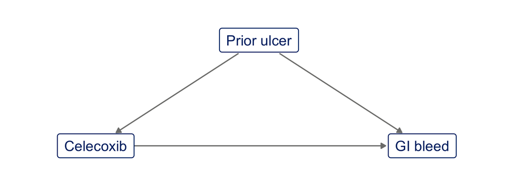

The arrow from celecoxib to GI bleed is the effect we want. The following path is a backdoor path:

celecoxib ← prior ulcer → GI bleed

Unless we adjust for prior ulcers, it would make celecoxib look more harmful than it is.

## Why Randomized Trials Work

- In a randomized controlled trial, chance alone decides who receives the treatment.
- As a result, the treated and untreated groups are expected to be the same at baseline in every respect, measured or not.
- Any systematic difference in outcomes between the groups can therefore be attributed to the treatment.

## The Structure of a Trial

In a trial, randomization is the only cause of treatment. Other causes of the outcome, such as age and sex, have no arrow into treatment.

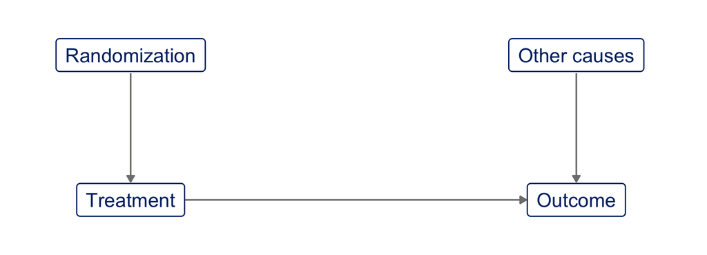

Because nothing else points into treatment, the only path from treatment to outcome is the direct one, and a simple comparison of the two groups estimates the treatment effect.

## Observational Data

In observational data, treatment is not assigned at random. Doctors and patients choose treatments for various reasons, from the state of evidence to limitations of insurance and the health system.

A **confounder** is a variable that affects both which treatment a person receives and the outcome.

## The Structure of Confounding

In observational data, a confounder adds an arrow into treatment.

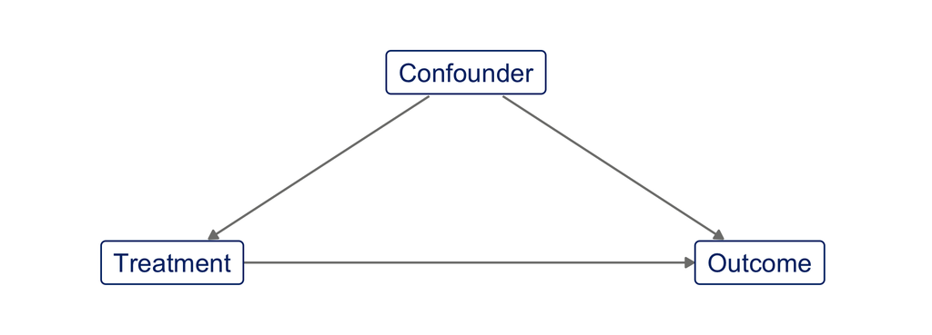

The confounder opens a backdoor path from treatment to outcome. Comparing treated and untreated patients without accounting for it mixes the two paths together, biasing the estimated effect size of the treatment.

## Confounding by Age and Sex

In today’s simulations, older patients and men are more likely to be treated. They are also more likely to have worse outcomes.

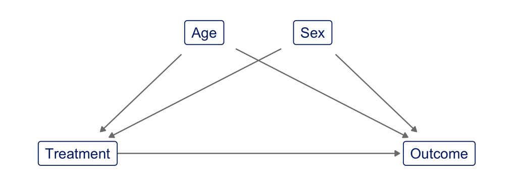

A comparison of treated and untreated patients that ignores age and sex mixes the effect of the treatment with the effects of age and sex.

# Different Research Outcomes, Different Models

## Four Common Models

The right model depends on the type of outcome being studied.

| Outcome | Example | Model | Treatment effect |
| --- | --- | --- | --- |
| Continuous | Blood pressure | Linear (OLS) | Difference in mean outcome |
| Binary | GI bleed | Logistic | Odds ratio |
| Count or rate | Number of ER visits | Poisson | Rate ratio |
| Time to event | Time until GI bleed | Cox | Hazard ratio |

## Conditional Effects

Each treatment effect is conditional on the other covariates in the model. It compares treated and untreated patients who have the same values of those covariates. You will often read statements like “all else equal” or “controlling for” to convey how covariates are adjusted.

## Learning With Simulation

- In a simulation, we choose the true effect of the treatment before generating the data.
- We can then check whether a method recovers that effect.
- Testing a method on simulated data shows how it behaves before we trust it on real data, where the true effect is unknown.
- I find this helps build understanding of how confounding actually works.

## Two Simulated Datasets

We build two datasets of 10,000 patients each and reuse them for every model.

- **`trial`**: a randomized trial. A coin flip decides treatment.
- **`obs`**: observational data. Age and sex affect both treatment and the outcome.

For each model, we add an outcome with a known treatment effect to both datasets. We then check whether the model recovers that effect.

# Linear Regression

## Linear Regression (OLS)

Linear regression models a continuous outcome as a straight-line function of the predictors.

- The **intercept** is the expected outcome when every predictor is zero.
- The **coefficient** on treatment is the expected difference in the outcome between treated and untreated patients who have the same values of the other predictors.

In the simulation, the outcome is systolic blood pressure, and the treatment lowers it by 5 mmHg.

## Simulating a Randomized Trial

```r
set.seed(21)
n <- 10000

# A coin flip assigns treatment: 1 = treated, 0 = untreated
trial <- data.frame(treated = rbinom(n, size = 1, prob = 0.5))

# Blood pressure averages 140; treatment lowers it by 5; rnorm() adds noise
trial$sbp <- 140 - 5 * trial$treated + rnorm(n, mean = 0, sd = 10)

head(trial, 4)
```

```
  treated      sbp
1       1 121.4889
2       0 131.8583
3       1 137.8211
4       0 139.7353
```

## Comparing the Two Groups

```r
ggplot(trial, aes(x = factor(treated), y = sbp)) +
  geom_jitter(width = 0.2, alpha = 0.08, color = "#68ACE5") +
  stat_summary(fun = mean, geom = "point", size = 5, color = "#002D72") +
  scale_x_discrete(labels = c("Untreated", "Treated")) +
  labs(x = NULL, y = "Systolic blood pressure (mmHg)")
```

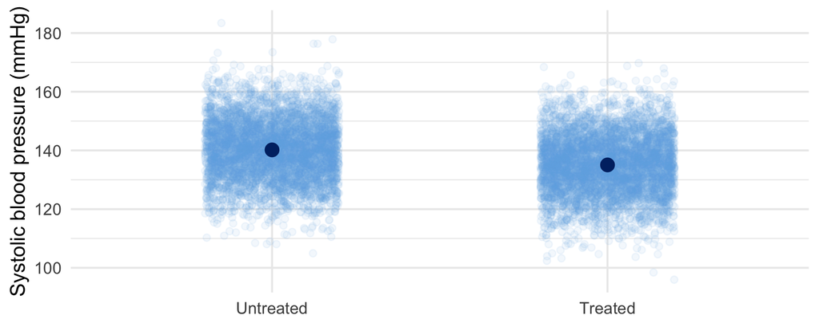

The dark points mark each group’s mean.

## Fitting the Model

`lm()` fits a linear regression. `coef()` returns the estimates, and `confint()` returns their 95% confidence intervals.

```r
fit_ols_trial <- lm(sbp ~ treated, data = trial)
round(cbind(estimate = coef(fit_ols_trial), confint(fit_ols_trial)), 2)
```

```
            estimate  2.5 % 97.5 %
(Intercept)   140.19 139.91 140.47
treated        -5.13  -5.52  -4.74
```

The coefficient on `treated` is close to the true effect of −5. With a single binary predictor, it equals the difference between the two group means:

```r
aggregate(sbp ~ treated, data = trial, FUN = mean)
```

```
  treated      sbp
1       0 140.1890
2       1 135.0591
```

## Simulating Observational Data

Now treatment depends on age and sex. `plogis()` converts a score into a probability between 0 and 1.

```r
obs <- data.frame(
  age = rnorm(n, mean = 60, sd = 10),
  male = rbinom(n, size = 1, prob = 0.5)
)

# Older patients and men are more likely to be treated
obs$treated <- rbinom(n, size = 1,
                      prob = plogis(-1.5 + (obs$age - 60) / 10 + obs$male))

aggregate(cbind(age, male) ~ treated, data = obs, FUN = mean)
```

```
  treated      age      male
1       0 57.26718 0.4286973
2       1 65.81325 0.6327170
```

Treated patients are older on average, and a larger share of them are men.

## A Confounded Outcome

Blood pressure rises with age and is higher in men. The treatment effect is still −5. Remember, we simulated the data ourselves, so we know this to be true.

```r
obs$sbp <- 100 + 0.7 * obs$age + 4 * obs$male - 5 * obs$treated +
  rnorm(n, mean = 0, sd = 10)
```

## Ignoring Age and Sex

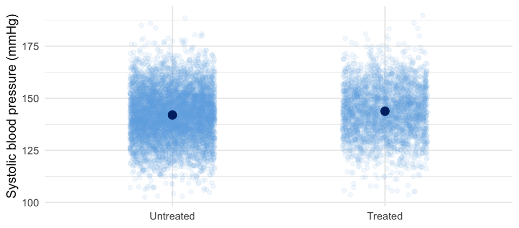

The treated group’s mean is *higher*. Taken at face value, the treatment appears to raise blood pressure.

## The Same Data, Broken Out by Age and Sex

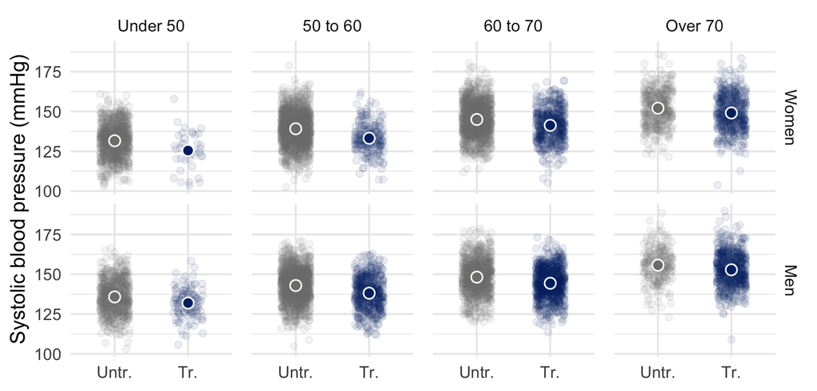

Within every panel, the treated mean is *lower*. The treated group looks worse overall only because it is older and has more men.

## The Unadjusted Model

Fitting the model with treatment alone reproduces the misleading comparison.

```r
fit_ols_naive <- lm(sbp ~ treated, data = obs)
round(cbind(estimate = coef(fit_ols_naive), confint(fit_ols_naive)), 2)
```

```
            estimate  2.5 % 97.5 %
(Intercept)   141.96 141.68 142.25
treated         1.81   1.30   2.31
```

The model estimates an effect of 1.8 mmHg. The true effect is −5.

## Adjusting for Age and Sex

Adding age and sex to the model compares treated and untreated patients of the same age and sex.

```r
fit_ols_adj <- lm(sbp ~ treated + age + male, data = obs)
round(cbind(estimate = coef(fit_ols_adj), confint(fit_ols_adj)), 2)
```

```
            estimate 2.5 % 97.5 %
(Intercept)   100.43 99.19 101.66
treated        -4.93 -5.39  -4.46
age             0.70  0.68   0.72
male            3.84  3.44   4.23
```

The adjusted estimate, −4.9 mmHg, is close to the true effect of −5.

# Logistic Regression

## Logistic Regression

Logistic regression models a binary outcome, such as whether a patient has a GI bleed.

- The **odds** of an event are the probability it happens divided by the probability it does not. A 20% risk is odds of 0.2 / 0.8 = 0.25.
- The model estimates coefficients on the **log odds** scale.
- Exponentiating a coefficient with `exp()` gives an **odds ratio**. An odds ratio of 2 means the treatment doubles the odds of the outcome.

In the simulation, the treatment doubles the odds of a GI bleed.

## Logistic: Randomized Trial

`rbinom()` draws a 0 or 1 for each patient, using the probability from `plogis()`.

```r
trial$bleed <- rbinom(n, size = 1, prob = plogis(-2 + log(2) * trial$treated))

fit_logit_trial <- glm(bleed ~ treated, family = binomial, data = trial)
round(exp(cbind(odds_ratio = coef(fit_logit_trial), confint(fit_logit_trial))), 2)
```

```
            odds_ratio 2.5 % 97.5 %
(Intercept)       0.14  0.13   0.15
treated           1.96  1.76   2.19
```

The odds ratio for `treated` is close to the true value of 2. The intercept row is the odds of a bleed among untreated patients.

## Logistic: Observational, Unadjusted

Older patients and men are also more likely to bleed.

```r
obs$bleed <- rbinom(n, size = 1, prob = plogis(
  -2 + log(2) * obs$treated + 0.05 * (obs$age - 60) + 0.5 * obs$male
))

fit_logit_naive <- glm(bleed ~ treated, family = binomial, data = obs)
round(exp(cbind(odds_ratio = coef(fit_logit_naive), confint(fit_logit_naive))), 2)
```

```
            odds_ratio 2.5 % 97.5 %
(Intercept)       0.15  0.14   0.16
treated           3.61  3.26   3.99
```

The unadjusted odds ratio, 3.61, overstates the harm of the treatment.

## Logistic: Observational, Adjusted

```r
fit_logit_adj <- glm(bleed ~ treated + age + male, family = binomial, data = obs)
round(exp(cbind(odds_ratio = coef(fit_logit_adj), confint(fit_logit_adj))), 2)
```

```
            odds_ratio 2.5 % 97.5 %
(Intercept)       0.01  0.00   0.01
treated           2.19  1.96   2.44
age               1.05  1.05   1.06
male              1.81  1.63   2.02
```

After adjustment, the odds ratio for `treated` is 2.19, close to the true value of 2. The `age` row is the odds ratio for each additional year of age.

# Poisson Regression

## Poisson Regression

Poisson regression models counts of events, such as the number of ER visits.

- Patients are followed for different lengths of time. A patient followed for three years has more time to visit the ER than one followed for six months.
- The model accounts for this with an **offset**: the log of each patient’s **person-time**.
- The model then estimates a **rate**, which for us is often an incidence rate.
- Exponentiating a coefficient gives a **rate ratio**.

In the simulation, the treatment raises the rate of ER visits by 50%, a rate ratio of 1.5.

## Poisson: Randomized Trial

Each patient is followed for between six months and three years. `rpois()` draws a count of visits from that patient’s rate and follow-up time.

```r
trial$years <- runif(n, min = 0.5, max = 3)
trial$visits <- rpois(n, lambda = 0.5 * 1.5^trial$treated * trial$years)

fit_pois_trial <- glm(visits ~ treated + offset(log(years)),
                      family = poisson, data = trial)
round(exp(cbind(rate_ratio = coef(fit_pois_trial), confint(fit_pois_trial))), 2)
```

```
            rate_ratio 2.5 % 97.5 %
(Intercept)       0.51  0.50   0.53
treated           1.48  1.42   1.53
```

The intercept row is the rate among untreated patients: about 0.5 visits per person-year.

## Poisson: Observational, Unadjusted

```r
obs$years <- runif(n, min = 0.5, max = 3)
obs$visits <- rpois(n, lambda = 0.5 * 1.5^obs$treated *
  exp(0.03 * (obs$age - 60) + 0.3 * obs$male) * obs$years)

fit_pois_naive <- glm(visits ~ treated + offset(log(years)),
                      family = poisson, data = obs)
round(exp(cbind(rate_ratio = coef(fit_pois_naive), confint(fit_pois_naive))), 2)
```

```
            rate_ratio 2.5 % 97.5 %
(Intercept)       0.55  0.54   0.56
treated           2.08  2.01   2.16
```

The unadjusted rate ratio is 2.08. The true value is 1.5.

## Poisson: Observational, Adjusted

```r
fit_pois_adj <- glm(visits ~ treated + age + male + offset(log(years)),
                    family = poisson, data = obs)
round(exp(cbind(rate_ratio = coef(fit_pois_adj), confint(fit_pois_adj))), 2)
```

```
            rate_ratio 2.5 % 97.5 %
(Intercept)       0.08  0.07   0.09
treated           1.51  1.45   1.57
age               1.03  1.03   1.03
male              1.41  1.36   1.46
```

After adjustment, the rate ratio is 1.51.

# Survival Analysis

## Survival Analysis

Survival analysis models the time until an event occurs.

- Some patients leave the data before the event can be observed, for example because they change insurance, switch systems, or die. This is called **censoring**. We know only that they had not had the event by the time they left.
- **Kaplan–Meier curves** show the proportion of each group that is still event-free over time.
- The **Cox model** estimates a **hazard ratio**: the ratio of the event rates in the two groups at any point in time.
- The Cox model assumes that this ratio is constant over time. This is the **proportional hazards** assumption.

In the simulation, the treatment doubles the hazard of a GI bleed.

## Data Requirements

Survival analysis needs one row per patient with at least three pieces of information.

- A **time zero**, the date follow-up starts. In OHDSI studies this is usually the cohort start date, when the patient begins treatment.
- A **follow-up time**, the time from time zero to the event or to the end of follow-up, whichever comes first.
- An **event indicator**, which is 1 if the event was observed and 0 if the patient was censored.

To compute these, we need the date of the outcome and the date each patient’s follow-up ends, such as the end of their observation period. The Cox model also assumes that censoring is unrelated to the risk of the event once we account for the covariates.

## Simulating Time to Event

`rexp()` draws each patient’s time to a GI bleed. A second draw sets when each patient leaves the data.

```r
bleed_time <- rexp(n, rate = 0.1 * 2^trial$treated)  # years
censor_time <- runif(n, min = 0, max = 5)

# We observe whichever comes first
trial$time <- pmin(bleed_time, censor_time)
trial$event <- as.integer(bleed_time <= censor_time)  # 1 = bleed, 0 = censored

head(trial[, c("treated", "time", "event")], 4)
```

```
  treated     time event
1       1 1.454757     0
2       0 1.854889     0
3       1 4.374877     0
4       0 1.075882     1
```

## Kaplan–Meier Curves

`Surv()` combines the follow-up time and the event indicator. `survfit()` estimates the curves.

```r
km <- survfit(Surv(time, event) ~ treated, data = trial)
km_data <- data.frame(time = km$time, surv = km$surv,
                      group = rep(c("Untreated", "Treated"), km$strata))

ggplot(km_data, aes(x = time, y = surv, color = group)) +
  geom_step(linewidth = 1.5) +
  scale_color_manual(values = c(Untreated = "#7E7E7C", Treated = "#002D72"), name = NULL) +
  labs(x = "Years since treatment start", y = "Proportion without a GI bleed")
```

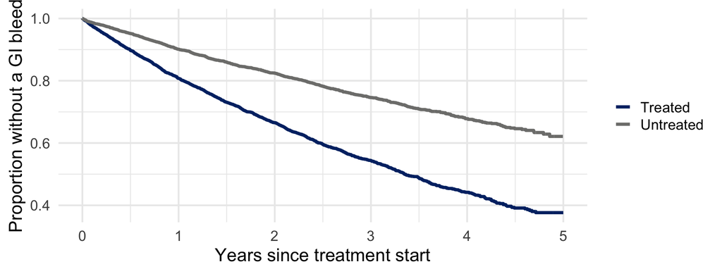

## Cox: Randomized Trial

`coxph()` fits the Cox model. Its output has no intercept.

```r
fit_cox_trial <- coxph(Surv(time, event) ~ treated, data = trial)
round(exp(cbind(hazard_ratio = coef(fit_cox_trial), confint(fit_cox_trial))), 2)
```

```
        hazard_ratio 2.5 % 97.5 %
treated          2.1  1.95   2.27
```

The hazard ratio is close to the true value of 2.

## Cox: Observational, Unadjusted

```r
bleed_time <- rexp(n, rate = 0.1 * 2^obs$treated *
  exp(0.05 * (obs$age - 60) + 0.5 * obs$male))
censor_time <- runif(n, min = 0, max = 5)
obs$time <- pmin(bleed_time, censor_time)
obs$event <- as.integer(bleed_time <= censor_time)

fit_cox_naive <- coxph(Surv(time, event) ~ treated, data = obs)
round(exp(cbind(hazard_ratio = coef(fit_cox_naive), confint(fit_cox_naive))), 2)
```

```
        hazard_ratio 2.5 % 97.5 %
treated         3.21     3   3.44
```

The unadjusted hazard ratio is 3.21. The true value is 2.

## Cox: Observational, Adjusted

```r
fit_cox_adj <- coxph(Surv(time, event) ~ treated + age + male, data = obs)
round(exp(cbind(hazard_ratio = coef(fit_cox_adj), confint(fit_cox_adj))), 2)
```

```
        hazard_ratio 2.5 % 97.5 %
treated         2.11  1.96   2.27
age             1.05  1.05   1.05
male            1.59  1.48   1.70
```

After adjustment, the hazard ratio is 2.11.

## Summary

| Model | Treatment effect | Truth | Trial | Observational, unadjusted | Observational, adjusted |
| --- | --- | --- | --- | --- | --- |
| Linear (OLS) | Difference in means | −5.00 | −5.13 | 1.81 | −4.93 |
| Logistic | Odds ratio | 2.00 | 1.96 | 3.61 | 2.19 |
| Poisson | Rate ratio | 1.50 | 1.48 | 2.08 | 1.51 |
| Cox | Hazard ratio | 2.00 | 2.10 | 3.21 | 2.11 |

In every model, the unadjusted estimate from observational data is biased. Adjusting for the confounders recovers the true effect.

# From Two Confounders to Thousands

## The Problem With Real Data

In the simulations, there were two confounders, and we knew what they were.

In OMOP data, each patient can have thousands of recorded conditions, drugs, procedures, and measurements. Any of them might be a confounder. Adding thousands of covariates to an outcome model is difficult to do well.

## Propensity Scores: A Preview

A **propensity score** is the probability that a patient receives the treatment, given their covariates.

- Patients with similar propensity scores have similar covariates, on average.
- Matching treated and untreated patients on the score produces groups that are comparable at baseline, as in a trial.
- The outcome model can then compare the matched groups directly, without adding the covariates.

## What Are We Estimating?

The **estimand** is the quantity a study sets out to estimate. For a treatment effect, the main question is: the effect *in whom*?

- **ATE**, the average treatment effect: the effect if *everyone* were treated versus no one
- **ATT**, the average treatment effect in the treated: the effect among patients who actually *received* the treatment
- **ATC**, the average treatment effect in the controls: the effect among patients who did *not* receive it

If the treatment works the same for everyone, the three are equal. When the effect differs across patients, and the treated differ from the untreated, they are not.

## Estimands and Propensity Scores

The estimand follows from how the propensity score is used.

- Matching each treated patient to an untreated patient estimates the **ATT**. This is the `matchit()` default.
- Matching each untreated patient to a treated patient estimates the **ATC** (`estimand = "ATC"`).
- Weighting the whole sample, or full matching, can estimate the **ATE** (`estimand = "ATE"`).

A caliper drops treated patients with no close match. The estimate then applies to the treated patients who *could* be matched, which can differ from all treated patients.

## Regression Hides Its Estimand

- An outcome model like `lm(sbp ~ treated + age + male)` returns one coefficient for treatment.
- If the effect differs across patients, that coefficient is a weighted average of the effect across covariate groups. It gives the most weight to groups where treatment is close to 50/50, which are not the treated, the untreated, or the whole population.
- This is true even when the model adjusts for every confounder.

Regression *can* target the ATE or ATT: fit the outcome model, predict each patient’s outcome treated and untreated, and average over the chosen population. That step has to be done on purpose. With propensity scores, the choice is part of the design.

## Matching on the Propensity Score

`matchit()` estimates each patient’s propensity score from age and sex. It then pairs each treated patient with the untreated patient whose score is closest, so the estimand is the ATT. The **caliper** sets how close two scores must be. Treated patients with no untreated patient within the caliper are dropped.

```r
matched <- matchit(treated ~ age + male, data = obs, caliper = 0.05)
matched_obs <- match.data(matched)

# Patients kept in each group
table(matched_obs$treated)
```

```
   0    1
2641 2641
```

## Age and Sex Before Matching

```r
aggregate(cbind(age, male) ~ treated, data = obs, FUN = mean)
```

```
  treated      age      male
1       0 57.26718 0.4286973
2       1 65.81325 0.6327170
```

The treated group is older and has more men. `male` is the proportion of men.

## Age and Sex After Matching

```r
aggregate(cbind(age, male) ~ treated, data = matched_obs, FUN = mean)
```

```
  treated      age      male
1       0 63.42086 0.6005301
2       1 63.62097 0.5948504
```

After matching, the two groups have nearly the same average age and share of men.

## Age Distribution Before and After Matching

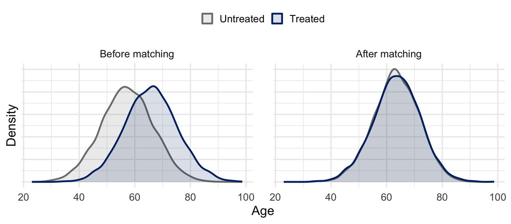

Before matching, the treated patients skew older. After matching, the two age distributions nearly overlap.

## The Outcome Model Before Matching

As a reminder, this is the unadjusted model on the full, unmatched data.

```r
round(cbind(estimate = coef(fit_ols_naive), confint(fit_ols_naive)), 2)
```

```
            estimate  2.5 % 97.5 %
(Intercept)   141.96 141.68 142.25
treated         1.81   1.30   2.31
```

The estimate is 1.8 mmHg, far from the true effect of −5.

## The Outcome Model After Matching

The outcome model contains only the treatment.

```r
fit_ps <- lm(sbp ~ treated, data = matched_obs)
round(cbind(estimate = coef(fit_ps), confint(fit_ps)), 2)
```

```
            estimate  2.5 % 97.5 %
(Intercept)   146.62 146.18 147.07
treated        -4.67  -5.30  -4.05
```

- The estimate is −4.7 mmHg. The true effect is −5, and the unadjusted estimate was 1.8.
- Note that with matching only, and no covariate adjustment, we are able to recover the treatment effect.

## Doubly Robust Estimation

We now have two ways to handle confounding:

- A **propensity score model**, which predicts treatment from the covariates
- An **outcome model**, which predicts the outcome from treatment and the covariates

Either one gives a biased answer if its model is wrong.

A **doubly robust** approach uses both. Its estimate stays unbiased if *either* model is correct, so the analysis gets two chances to get it right.

## A Misspecified Propensity Score

Suppose we leave sex out of the propensity score model.

```r
matched_bad <- matchit(treated ~ age, data = obs, caliper = 0.05)
matched_bad_obs <- match.data(matched_bad)

aggregate(cbind(age, male) ~ treated, data = matched_bad_obs, FUN = mean)
```

```
  treated      age      male
1       0 63.76253 0.4169649
2       1 63.86735 0.6481747
```

Age is balanced, but the treated group still has more men.

## The Outcome Model With the Wrong Score

With only the treatment in the outcome model, the leftover imbalance in sex biases the estimate.

```r
fit_ps_bad <- lm(sbp ~ treated, data = matched_bad_obs)
round(cbind(estimate = coef(fit_ps_bad), confint(fit_ps_bad)), 2)
```

```
            estimate  2.5 % 97.5 %
(Intercept)   146.30 145.87 146.73
treated        -3.98  -4.59  -3.38
```

The estimate is −4.0 mmHg. The true effect is −5.

## Matching Plus Covariate Adjustment

Now we keep the same flawed matches, but adjust for age and sex in the outcome model.

```r
fit_dr <- lm(sbp ~ treated + age + male, data = matched_bad_obs)
round(cbind(estimate = coef(fit_dr), confint(fit_dr)), 2)
```

```
            estimate 2.5 % 97.5 %
(Intercept)    99.81 97.69 101.92
treated        -4.91 -5.45  -4.37
age             0.70  0.67   0.74
male            3.70  3.16   4.24
```

The estimate is −4.9 mmHg. The propensity score model was wrong, but the outcome model was right, so the estimate is still close to −5.

## Many Covariates, Few Patients

- In OMOP data, every condition, drug, procedure, and measurement code can become a covariate. CohortMethod routinely builds tens of thousands of them.
- Many codes record the same underlying fact. A diagnosis of type 2 diabetes, a metformin prescription, and an HbA1c test all point to diabetes.
- For a rare exposure or a small database, there can be fewer patients than covariates.
- Ordinary logistic regression cannot estimate a propensity score in that setting.

## Simulating High-Dimensional Data

This data set has 500 patients and 1,000 binary codes. Each of 20 underlying conditions is recorded by 50 related codes. Three conditions drive both treatment and blood pressure. The true effect is again −5.

```r
set.seed(7)
n_patients <- 500
n_conditions <- 20
codes_per_condition <- 50

condition <- matrix(rbinom(n_patients * n_conditions, size = 1, prob = 0.25), ncol = n_conditions)

# A patient with the condition usually has each related code; others rarely do
codes <- lapply(seq_len(n_conditions), function(k) {
  prob <- ifelse(condition[, k] == 1, 0.6, 0.02)
  matrix(rbinom(n_patients * codes_per_condition, size = 1, prob = prob), ncol = codes_per_condition)
})
codes <- do.call(cbind, codes)
colnames(codes) <- sprintf("code_%04d", seq_len(ncol(codes)))

treated <- rbinom(n_patients, size = 1,
                  prob = plogis(-1 + 1.5 * condition[, 1] + 1.5 * condition[, 2] - condition[, 3]))
sbp <- 130 - 5 * treated + 8 * condition[, 1] + 6 * condition[, 2] - 4 * condition[, 3] +
  rnorm(n_patients, sd = 10)

hd <- data.frame(treated, sbp, codes)
ps_formula <- reformulate(colnames(codes), response = "treated")
```

## A Standard Propensity Score Fails

```r
fit_ps_glm <- glm(ps_formula, family = binomial, data = hd)

# Coefficients that could not be estimated
sum(is.na(coef(fit_ps_glm)))
```

```
[1] 501
```

```r
# Estimated propensity scores
round(range(fitted(fit_ps_glm)), 3)
```

```
[1] 0 1
```

With more covariates than patients, the model cannot estimate half its coefficients, and the scores it does produce are pushed to 0 and 1. These scores cannot be used to match patients. `matchit()` fits this same model by default.

## The Lasso

- The **lasso** is logistic regression with a penalty on the size of the coefficients.
- The penalty shrinks most coefficients to exactly zero. The model keeps only the covariates that help predict treatment.
- Cross-validation picks how strong the penalty should be.
- Among a cluster of related codes, the lasso tends to keep a few and drop the rest.
- CohortMethod fits its propensity scores this way, using a regularized regression package called Cyclops.

## Lasso Propensity Scores in `matchit()`

Setting `distance = "lasso"` fits the propensity score with the lasso. It uses the glmnet package.

```r
matched_hd <- matchit(ps_formula, data = hd, distance = "lasso", caliper = 0.05)
matched_hd_obs <- match.data(matched_hd)
table(matched_hd_obs$treated)
```

```
  0   1
119 119
```

```r
fit_hd <- lm(sbp ~ treated, data = matched_hd_obs)
round(cbind(estimate = coef(fit_hd), confint(fit_hd)), 2)
```

```
            estimate  2.5 % 97.5 %
(Intercept)   133.60 131.54 135.66
treated        -5.73  -8.64  -2.82
```

## Friday

- The logic of propensity scores in more detail
- CohortMethod on OMOP data, using the Eunomia GI bleed example
- Diagnostics for checking whether a study can be trusted
- Running the same analysis across a data network with Strategus